# Predictive Maintenance Modeling

## Problem Description

A major problem faced by businesses in asset-heavy industries such as manufacturing is the significant costs that are associated with delays in the production process due to mechanical problems. Most of these businesses are interested in predicting these problems in advance so that they can proactively prevent the problems before they occur which will reduce the costly impact caused by downtime. Please refer to the [playbook for predictive maintenance](https://azure.microsoft.com/en-us/documentation/articles/cortana-analytics-playbook-predictive-maintenance/) for a detailed explanation of common use cases in predictive maintenance and modeling approaches.

In this notebook, we follow the ideas from the playbook referenced above and aim to provide the steps of implementing a predictive model for a scenario which is based on a synthesis of multiple real-world business problems. This example brings together common data elements observed among many predictive maintenance use cases and the data itself is created by data simulation methods.

The business problem for this example is about predicting problems caused by component failures such that the question "What is the probability that a machine will fail in the near future due to a failure of a certain component?" can be answered. The problem is formatted as a multi-class classification problem and a machine learning algorithm is used to create the predictive model that learns from historical data collected from machines. In the following sections, we go through the steps of implementing such a model which are feature engineering, label construction, training and evaluation. First, we start by explaining the data sources in the next section.

## Data Sources

Common data sources for predictive maintenance problems are :

- Failure history: The failure history of a machine or component within the machine.
- Maintenance history: The repair history of a machine, e.g. error codes, previous maintenance activities or component replacements.
- Machine conditions and usage: The operating conditions of a machine e.g. data collected from sensors.
- Machine features: The features of a machine, e.g. engine size, make and model, location.
- Operator features: The features of the operator, e.g. gender, past experience

The data for this example comes from 4 different sources which are real-time telemetry data collected from machines, error messages, historical maintenance records that include failures and machine information such as type and age.

```python
import pandas as pd



telemetry = pd.read_csv('Downloads\\PdM_telemetry_m.csv')
errors = pd.read_csv('Downloads\\PdM_errors_m.csv')
maint = pd.read_csv('Downloads\\PdM_maint_m.csv')
failures = pd.read_csv('Downloads\\PdM_failures_m.csv')
machines = pd.read_csv('Downloads\\PdM_machines.csv')
```

### Telemetry

```python
# format datetime field which comes in as string
telemetry['datetime'] = pd.to_datetime(telemetry['datetime'])

print('Total number of telemetry records: {}'.format(len(telemetry.index)))
print(telemetry.head())
telemetry.describe()
```

```
Total number of telemetry records: 141100
             datetime  machineID        volt      rotate    pressure  \
0 2015-01-01 06:00:00          1  176.217853  418.504078  113.077935
1 2015-01-01 07:00:00          1  162.879223  402.747490   95.460525
2 2015-01-01 08:00:00          1  170.989902  527.349825   75.237905
3 2015-01-01 09:00:00          1  162.462833  346.149335  109.248561
4 2015-01-01 10:00:00          1  157.610021  435.376873  111.886648

   vibration
0  45.087686
1  43.413973
2  34.178847
3  41.122144
4  25.990511
```

|  | machineID | volt | rotate | pressure | vibration |
| --- | --- | --- | --- | --- | --- |
| count | 141100.000000 | 141100.000000 | 141100.000000 | 141100.000000 | 141100.000000 |
| mean | 50.500000 | 170.871494 | 446.756542 | 100.861521 | 40.341308 |
| std | 28.866172 | 15.530152 | 52.512735 | 11.035530 | 5.328316 |
| min | 1.000000 | 98.337989 | 167.099106 | 55.522624 | 19.001969 |
| 25% | 25.750000 | 160.363559 | 412.684580 | 93.491837 | 36.747397 |
| 50% | 50.500000 | 170.696848 | 447.752326 | 100.418565 | 40.210708 |
| 75% | 75.250000 | 181.087612 | 482.151358 | 107.568767 | 43.753188 |
| max | 100.000000 | 246.419957 | 655.697385 | 174.789490 | 73.948949 |

```python
telemetry.shape
```

```
(141100, 6)
```

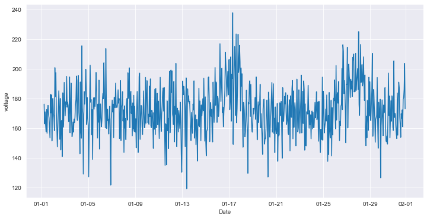

```python
%matplotlib inline
import matplotlib.pyplot as plt
import seaborn as sns

plot_df = telemetry.loc[(telemetry['machineID'] == 1) &
                        (telemetry['datetime'] > pd.to_datetime('2015-01-01')) &
                        (telemetry['datetime'] < pd.to_datetime('2015-02-01')), ['datetime', 'volt']]

sns.set_style("darkgrid")
plt.figure(figsize=(12, 6))
plt.plot(plot_df['datetime'], plot_df['volt'])
plt.ylabel('voltage')

# make x-axis ticks legible
adf = plt.gca().get_xaxis().get_major_formatter()
adf.scaled[1.0] = '%m-%d'
plt.xlabel('Date')
```

### Errors

The second major data source is the error logs. These are non-breaking errors thrown while the machine is still operational and do not constitute as failures. The error date and times are rounded to the closest hour since the telemetry data is collected at an hourly rate.

```python
# format datetime field which comes in as string
errors['datetime'] = pd.to_datetime(errors['datetime'])
errors['errorID'] = errors['errorID'].astype('category')

print('Total number of error records: {}'.format(len(errors.index)))
errors.head()
```

```
Total number of error records: 647
```

|  | datetime | machineID | errorID |
| --- | --- | --- | --- |
| 0 | 2015-01-03 07:00:00 | 1 | error1 |
| 1 | 2015-01-03 20:00:00 | 1 | error3 |
| 2 | 2015-01-04 06:00:00 | 1 | error5 |
| 3 | 2015-01-10 15:00:00 | 1 | error4 |
| 4 | 2015-01-22 10:00:00 | 1 | error4 |

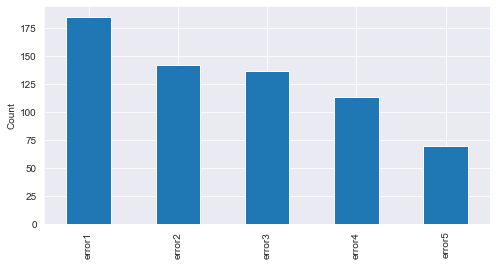

```python
sns.set_style("darkgrid")
plt.figure(figsize=(8, 4))
errors['errorID'].value_counts().plot(kind='bar')
plt.ylabel('Count')
```

### Maintenance

These are the scheduled and unscheduled maintenance records which correspond to both regular inspection of components as well as failures. A record is generated if a component is replaced during the scheduled inspection or replaced due to a breakdown. The records that are created due to breakdowns will be called failures which is explained in the later sections. Maintenance data has both 2014 and 2015 records.

```python
# format datetime field which comes in as string
maint['datetime'] = pd.to_datetime(maint['datetime'])
maint['comp'] = maint['comp'].astype('category')

print('Total number of maintenance records: {}'.format(len(maint.index)))
maint.head()
```

```
Total number of maintenance records: 3286
```

|  | datetime | machineID | comp |
| --- | --- | --- | --- |
| 0 | 2014-06-01 06:00:00 | 1 | comp2 |
| 1 | 2014-07-16 06:00:00 | 1 | comp4 |
| 2 | 2014-07-31 06:00:00 | 1 | comp3 |
| 3 | 2014-12-13 06:00:00 | 1 | comp1 |
| 4 | 2015-01-05 06:00:00 | 1 | comp4 |

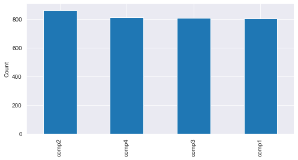

```python
sns.set_style("darkgrid")
plt.figure(figsize=(8, 4))
maint['comp'].value_counts().plot(kind='bar')
plt.ylabel('Count')
```

### Machines

This data set includes some information about the machines: model type and age (years in service).

```python
machines['model'] = machines['model'].astype('category')

print('Total number of machines: {}'.format(len(machines.index)))
machines.head()
```

```
Total number of machines: 100
```

|  | machineID | model | age |
| --- | --- | --- | --- |
| 0 | 1 | model3 | 18 |
| 1 | 2 | model4 | 7 |
| 2 | 3 | model3 | 8 |
| 3 | 4 | model3 | 7 |
| 4 | 5 | model3 | 2 |

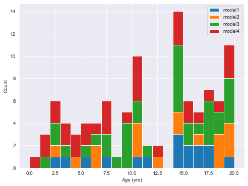

```python
sns.set_style("darkgrid")
plt.figure(figsize=(8, 6))
_, bins, _ = plt.hist([machines.loc[machines['model'] == 'model1', 'age'],
                       machines.loc[machines['model'] == 'model2', 'age'],
                       machines.loc[machines['model'] == 'model3', 'age'],
                       machines.loc[machines['model'] == 'model4', 'age']],
                       20, stacked=True, label=['model1', 'model2', 'model3', 'model4'])
plt.xlabel('Age (yrs)')
plt.ylabel('Count')
plt.legend()
```

### Failures

These are the records of component replacements due to failures. Each record has a date and time, machine ID, and failed component type.

```python
# format datetime field which comes in as string
failures['datetime'] = pd.to_datetime(failures['datetime'])
failures['failure'] = failures['failure'].astype('category')

print('Total number of failures: {}'.format(len(failures.index)))
failures.head()
```

```
Total number of failures: 761
```

|  | datetime | machineID | failure |
| --- | --- | --- | --- |
| 0 | 2015-01-05 06:00:00 | 1 | comp4 |
| 1 | 2015-03-06 06:00:00 | 1 | comp1 |
| 2 | 2015-04-20 06:00:00 | 1 | comp2 |
| 3 | 2015-06-19 06:00:00 | 1 | comp4 |
| 4 | 2015-09-02 06:00:00 | 1 | comp4 |

Below is the histogram of the failures due to each component. We see that the most failures happen due to component 2.

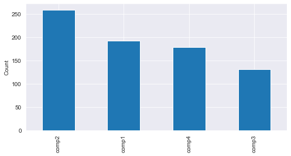

```python
sns.set_style("darkgrid")
plt.figure(figsize=(8, 4))
failures['failure'].value_counts().plot(kind='bar')
plt.ylabel('Count')
```

## Feature Engineering

The first step in predictive maintenance applications is feature engineering which requires bringing the different data sources together to create features that best describe a machines's health condition at a given point in time. In the next sections, several feature engineering methods are used to create features based on the properties of each data source.

### Lag Features from Telemetry

Telemetry data almost always comes with time-stamps which makes it suitable for calculating lagging features. A common method is to pick a window size for the lag features to be created and compute rolling aggregate measures such as mean, standard deviation, minimum, maximum, etc. to represent the short term history of the telemetry over the lag window. In the following, rolling mean and standard deviation of the telemetry data over the last 3 hour lag window is calculated for every 3 hours.

```python
# Calculate mean values for telemetry features
temp = []
fields = ['volt', 'rotate', 'pressure', 'vibration']
for col in fields:
    temp.append(pd.pivot_table(telemetry,
                               index='datetime',
                               columns='machineID',
                               values=col).resample('3H', closed='left', label='right').mean().unstack())
telemetry_mean_3h = pd.concat(temp, axis=1)
telemetry_mean_3h.columns = [i + 'mean_3h' for i in fields]
telemetry_mean_3h.reset_index(inplace=True)

# repeat for standard deviation
temp = []
for col in fields:
    temp.append(pd.pivot_table(telemetry,
                               index='datetime',
                               columns='machineID',
                               values=col).resample('3H', closed='left', label='right').std().unstack())
telemetry_sd_3h = pd.concat(temp, axis=1)
telemetry_sd_3h.columns = [i + 'sd_3h' for i in fields]
telemetry_sd_3h.reset_index(inplace=True)

telemetry_mean_3h.head()
```

|  | machineID | datetime | voltmean_3h | rotatemean_3h | pressuremean_3h | vibrationmean_3h |
| --- | --- | --- | --- | --- | --- | --- |
| 0 | 1 | 2015-01-01 09:00:00 | 170.028993 | 449.533798 | 94.592122 | 40.893502 |
| 1 | 1 | 2015-01-01 12:00:00 | 164.192565 | 403.949857 | 105.687417 | 34.255891 |
| 2 | 1 | 2015-01-01 15:00:00 | 168.134445 | 435.781707 | 107.793709 | 41.239405 |
| 3 | 1 | 2015-01-01 18:00:00 | 165.514453 | 430.472823 | 101.703289 | 40.373739 |
| 4 | 1 | 2015-01-01 21:00:00 | 168.809347 | 437.111120 | 90.911060 | 41.738542 |

For capturing a longer term effect, 24 hour lag features are also calculated as below.

```python
# Calculate mean values for telemetry features
temp = []
fields = ['volt', 'rotate', 'pressure', 'vibration']
for col in fields:
    temp.append(pd.pivot_table(telemetry,
                               index='datetime',
                               columns='machineID',
                               values=col).rolling(window=24).mean().resample('3H',
                                                                              closed='left',
                                                                              label='right').first().unstack())
telemetry_mean_24h = pd.concat(temp, axis=1)
telemetry_mean_24h.columns = [i + 'mean_24h' for i in fields]
telemetry_mean_24h.reset_index(inplace=True)
telemetry_mean_24h = telemetry_mean_24h.loc[-telemetry_mean_24h['voltmean_24h'].isnull()]

# repeat for standard deviation
temp = []
fields = ['volt', 'rotate', 'pressure', 'vibration']
for col in fields:
    temp.append(pd.pivot_table(telemetry,
                               index='datetime',
                               columns='machineID',
                               values=col).rolling(window=24).std().resample('3H',
                                                                             closed='left',
                                                                             label='right').first().unstack())
telemetry_sd_24h = pd.concat(temp, axis=1)
telemetry_sd_24h.columns = [i + 'sd_24h' for i in fields]
telemetry_sd_24h.reset_index(inplace=True)
telemetry_sd_24h = telemetry_sd_24h.loc[-telemetry_sd_24h['voltsd_24h'].isnull()]

# Notice that a 24h rolling average is not available at the earliest timepoints
telemetry_mean_24h.head(10)
```

|  | machineID | datetime | voltmean_24h | rotatemean_24h | pressuremean_24h | vibrationmean_24h |
| --- | --- | --- | --- | --- | --- | --- |
| 7 | 1 | 2015-01-02 06:00:00 | 169.733809 | 445.179865 | 96.797113 | 40.385160 |
| 8 | 1 | 2015-01-02 09:00:00 | 170.614862 | 446.364859 | 96.849785 | 39.736826 |
| 9 | 1 | 2015-01-02 12:00:00 | 169.893965 | 447.009407 | 97.715600 | 39.498374 |
| 10 | 1 | 2015-01-02 15:00:00 | 171.243444 | 444.233563 | 96.666060 | 40.229370 |
| 11 | 1 | 2015-01-02 18:00:00 | 170.792486 | 448.440437 | 95.766838 | 40.055214 |
| 12 | 1 | 2015-01-02 21:00:00 | 170.556674 | 452.267095 | 98.065860 | 40.033247 |
| 13 | 1 | 2015-01-03 00:00:00 | 168.460525 | 451.031783 | 99.273286 | 38.903462 |
| 14 | 1 | 2015-01-03 03:00:00 | 169.772951 | 447.502464 | 99.005946 | 39.389725 |
| 15 | 1 | 2015-01-03 06:00:00 | 170.900562 | 453.864597 | 100.877342 | 38.696225 |
| 16 | 1 | 2015-01-03 09:00:00 | 169.533156 | 454.785072 | 100.050567 | 39.449734 |

Next, the columns of the feature datasets created earlier are merged to create the final feature set from telemetry.

```python
# merge columns of feature sets created earlier
telemetry_feat = pd.concat([telemetry_mean_3h,
                            telemetry_sd_3h.iloc[:, 2:6],
                            telemetry_mean_24h.iloc[:, 2:6],
                            telemetry_sd_24h.iloc[:, 2:6]], axis=1).dropna()
telemetry_feat.describe()
```

|  | machineID | voltmean_3h | rotatemean_3h | pressuremean_3h | vibrationmean_3h | voltsd_3h | rotatesd_3h | pressuresd_3h | vibrationsd_3h | voltmean_24h | rotatemean_24h | pressuremean_24h | vibrationmean_24h | voltsd_24h | rotatesd_24h | pressuresd_24h | vibrationsd_24h |
| --- | --- | --- | --- | --- | --- | --- | --- | --- | --- | --- | --- | --- | --- | --- | --- | --- | --- |
| count | 46300.000000 | 46300.000000 | 46300.000000 | 46300.000000 | 46300.000000 | 46300.000000 | 46300.000000 | 46300.000000 | 46300.000000 | 46300.000000 | 46300.000000 | 46300.000000 | 46300.000000 | 46300.000000 | 46300.000000 | 46300.000000 | 46300.000000 |
| mean | 50.500000 | 170.834354 | 446.808217 | 100.840577 | 40.336134 | 13.286288 | 44.492344 | 8.872805 | 4.439965 | 170.855866 | 446.784171 | 100.850404 | 40.338904 | 14.917184 | 49.903928 | 10.023402 | 4.990959 |
| std | 28.866382 | 9.532248 | 32.761524 | 7.381879 | 3.396270 | 6.969903 | 23.280432 | 4.620642 | 2.319048 | 4.765477 | 17.698641 | 4.721533 | 1.963032 | 2.286740 | 7.724585 | 1.725094 | 0.800299 |
| min | 1.000000 | 125.532506 | 241.059832 | 74.985353 | 28.303651 | 0.054564 | 0.231672 | 0.061942 | 0.023625 | 157.615449 | 271.483011 | 91.573411 | 35.060087 | 7.100851 | 22.489771 | 4.573818 | 2.297777 |
| 25% | 25.750000 | 164.505897 | 427.884865 | 96.215852 | 38.150084 | 7.971937 | 26.829877 | 5.395236 | 2.685144 | 168.116670 | 441.613740 | 98.645051 | 39.348058 | 13.334383 | 44.587960 | 8.895107 | 4.444348 |
| 50% | 50.500000 | 170.431163 | 448.547398 | 100.183663 | 40.119341 | 12.495207 | 41.727125 | 8.341674 | 4.173131 | 170.264423 | 449.341968 | 100.064348 | 40.070066 | 14.878037 | 49.565379 | 9.884483 | 4.956274 |
| 75% | 75.250000 | 176.695218 | 468.351206 | 104.407526 | 42.198511 | 17.660807 | 59.120203 | 11.735214 | 5.893657 | 172.523804 | 456.406293 | 101.583746 | 40.820835 | 16.411850 | 54.837166 | 10.944297 | 5.475523 |
| max | 100.000000 | 228.679545 | 565.838073 | 156.298719 | 65.590984 | 56.063212 | 179.903039 | 34.401601 | 16.280104 | 210.834915 | 494.981214 | 141.961885 | 60.607395 | 26.250485 | 88.703301 | 23.244092 | 10.070082 |

```python
telemetry_feat.head()
```

|  | machineID | datetime | voltmean_3h | rotatemean_3h | pressuremean_3h | vibrationmean_3h | voltsd_3h | rotatesd_3h | pressuresd_3h | vibrationsd_3h | voltmean_24h | rotatemean_24h | pressuremean_24h | vibrationmean_24h | voltsd_24h | rotatesd_24h | pressuresd_24h | vibrationsd_24h |
| --- | --- | --- | --- | --- | --- | --- | --- | --- | --- | --- | --- | --- | --- | --- | --- | --- | --- | --- |
| 7 | 1 | 2015-01-02 06:00:00 | 180.133784 | 440.608320 | 94.137969 | 41.551544 | 21.322735 | 48.770512 | 2.135684 | 10.037208 | 169.733809 | 445.179865 | 96.797113 | 40.385160 | 11.233120 | 48.717395 | 10.079880 | 5.853209 |
| 8 | 1 | 2015-01-02 09:00:00 | 176.364293 | 439.349655 | 101.553209 | 36.105580 | 18.952210 | 51.329636 | 13.789279 | 6.737739 | 170.614862 | 446.364859 | 96.849785 | 39.736826 | 12.519402 | 48.385076 | 10.171540 | 6.163231 |
| 9 | 1 | 2015-01-02 12:00:00 | 160.384568 | 424.385316 | 99.598722 | 36.094637 | 13.047080 | 13.702496 | 9.988609 | 1.639962 | 169.893965 | 447.009407 | 97.715600 | 39.498374 | 13.370357 | 42.432317 | 9.471669 | 6.195076 |
| 10 | 1 | 2015-01-02 15:00:00 | 170.472461 | 442.933997 | 102.380586 | 40.483002 | 16.642354 | 56.290447 | 3.305739 | 8.854145 | 171.243444 | 444.233563 | 96.666060 | 40.229370 | 13.299281 | 41.346121 | 8.731229 | 5.687944 |
| 11 | 1 | 2015-01-02 18:00:00 | 163.263806 | 468.937558 | 102.726648 | 40.921802 | 17.424688 | 38.680380 | 9.105775 | 3.060781 | 170.792486 | 448.440437 | 95.766838 | 40.055214 | 13.954518 | 43.490234 | 8.061653 | 5.898069 |

### Lag Features from Errors

Like telemetry data, errors come with timestamps. An important difference is that the error IDs are categorical values and should not be averaged over time intervals like the telemetry measurements. Instead, we count the number of errors of each type in a lagging window. We begin by reformatting the error data to have one entry per machine per time at which at least one error occurred:

```python
# create a column for each error type
error_count = pd.get_dummies(errors)
error_count.columns = ['datetime', 'machineID', 'error1', 'error2', 'error3', 'error4', 'error5']

# combine errors for a given machine in a given hour
error_count = error_count.groupby(['machineID', 'datetime']).sum().reset_index()
error_count.head(13)
```

|  | machineID | datetime | error1 | error2 | error3 | error4 | error5 |
| --- | --- | --- | --- | --- | --- | --- | --- |
| 0 | 1 | 2015-01-03 07:00:00 | 1 | 0 | 0 | 0 | 0 |
| 1 | 1 | 2015-01-03 20:00:00 | 0 | 0 | 1 | 0 | 0 |
| 2 | 1 | 2015-01-04 06:00:00 | 0 | 0 | 0 | 0 | 1 |
| 3 | 1 | 2015-01-10 15:00:00 | 0 | 0 | 0 | 1 | 0 |
| 4 | 1 | 2015-01-22 10:00:00 | 0 | 0 | 0 | 1 | 0 |
| 5 | 1 | 2015-01-25 15:00:00 | 0 | 0 | 0 | 1 | 0 |
| 6 | 1 | 2015-01-27 04:00:00 | 1 | 0 | 0 | 0 | 0 |
| 7 | 2 | 2015-01-12 14:00:00 | 0 | 0 | 0 | 1 | 0 |
| 8 | 2 | 2015-02-06 10:00:00 | 0 | 0 | 0 | 1 | 0 |
| 9 | 2 | 2015-02-11 11:00:00 | 1 | 0 | 0 | 0 | 0 |
| 10 | 3 | 2015-01-06 06:00:00 | 0 | 1 | 1 | 0 | 0 |
| 11 | 3 | 2015-01-08 02:00:00 | 1 | 0 | 0 | 0 | 0 |
| 12 | 3 | 2015-01-11 05:00:00 | 1 | 0 | 0 | 0 | 0 |

Now we add blank entries for all other hourly timepoints (since no errors occurred at those times):

```python
error_count = telemetry[['datetime', 'machineID']].merge(error_count, on=['machineID', 'datetime'], how='left').fillna(0.0)
error_count.describe()
```

|  | machineID | error1 | error2 | error3 | error4 | error5 |
| --- | --- | --- | --- | --- | --- | --- |
| count | 141100.000000 | 141100.000000 | 141100.000000 | 141100.000000 | 141100.000000 | 141100.000000 |
| mean | 50.500000 | 0.001311 | 0.001006 | 0.000971 | 0.000801 | 0.000496 |
| std | 28.866172 | 0.036186 | 0.031708 | 0.031145 | 0.028288 | 0.022268 |
| min | 1.000000 | 0.000000 | 0.000000 | 0.000000 | 0.000000 | 0.000000 |
| 25% | 25.750000 | 0.000000 | 0.000000 | 0.000000 | 0.000000 | 0.000000 |
| 50% | 50.500000 | 0.000000 | 0.000000 | 0.000000 | 0.000000 | 0.000000 |
| 75% | 75.250000 | 0.000000 | 0.000000 | 0.000000 | 0.000000 | 0.000000 |
| max | 100.000000 | 1.000000 | 1.000000 | 1.000000 | 1.000000 | 1.000000 |

Finally, we can compute the total number of errors of each type over the last 24 hours, for timepoints taken every three hours:

```python
temp = []
fields = ['error%d' % i for i in range(1,6)]
for col in fields:
    temp.append(pd.pivot_table(error_count,
                               index='datetime',
                               columns='machineID',
                               values=col).rolling(window=24).sum().resample('3H',
                                                                             closed='left',
                                                                             label='right').first().unstack())
error_count = pd.concat(temp, axis=1)
error_count.columns = [i + 'count' for i in fields]
error_count.reset_index(inplace=True)
error_count = error_count.dropna()
error_count.describe()
```

|  | machineID | error1count | error2count | error3count | error4count | error5count |
| --- | --- | --- | --- | --- | --- | --- |
| count | 46400.000000 | 46400.000000 | 46400.000000 | 46400.000000 | 46400.000000 | 46400.000000 |
| mean | 50.500000 | 0.031401 | 0.024246 | 0.023168 | 0.019095 | 0.011767 |
| std | 28.866381 | 0.175386 | 0.156177 | 0.150725 | 0.138426 | 0.109228 |
| min | 1.000000 | 0.000000 | 0.000000 | 0.000000 | 0.000000 | 0.000000 |
| 25% | 25.750000 | 0.000000 | 0.000000 | 0.000000 | 0.000000 | 0.000000 |
| 50% | 50.500000 | 0.000000 | 0.000000 | 0.000000 | 0.000000 | 0.000000 |
| 75% | 75.250000 | 0.000000 | 0.000000 | 0.000000 | 0.000000 | 0.000000 |
| max | 100.000000 | 2.000000 | 2.000000 | 2.000000 | 2.000000 | 2.000000 |

```python
error_count.head()
```

|  | machineID | datetime | error1count | error2count | error3count | error4count | error5count |
| --- | --- | --- | --- | --- | --- | --- | --- |
| 7 | 1 | 2015-01-02 06:00:00 | 0.0 | 0.0 | 0.0 | 0.0 | 0.0 |
| 8 | 1 | 2015-01-02 09:00:00 | 0.0 | 0.0 | 0.0 | 0.0 | 0.0 |
| 9 | 1 | 2015-01-02 12:00:00 | 0.0 | 0.0 | 0.0 | 0.0 | 0.0 |
| 10 | 1 | 2015-01-02 15:00:00 | 0.0 | 0.0 | 0.0 | 0.0 | 0.0 |
| 11 | 1 | 2015-01-02 18:00:00 | 0.0 | 0.0 | 0.0 | 0.0 | 0.0 |

### Days Since Last Replacement from Maintenance

A crucial data set in this example is the maintenance records which contain the information of component replacement records. Possible features from this data set can be, for example, the number of replacements of each component in the last 3 months to incorporate the frequency of replacements. However, more relevent information would be to calculate how long it has been since a component is last replaced as that would be expected to correlate better with component failures since the longer a component is used, the more degradation should be expected.

As a side note, creating lagging features from maintenance data is not as straightforward as for telemetry and errors, so the features from this data are generated in a more custom way. This type of ad-hoc feature engineering is very common in predictive maintenance since domain knowledge plays a big role in understanding the predictors of a problem. In the following, the days since last component replacement are calculated for each component type as features from the maintenance data.

```python
import numpy as np

# create a column for each error type
comp_rep = pd.get_dummies(maint)
comp_rep.columns = ['datetime', 'machineID', 'comp1', 'comp2', 'comp3', 'comp4']

# combine repairs for a given machine in a given hour
comp_rep = comp_rep.groupby(['machineID', 'datetime']).sum().reset_index()

# add timepoints where no components were replaced
comp_rep = telemetry[['datetime', 'machineID']].merge(comp_rep,
                                                      on=['datetime', 'machineID'],
                                                      how='outer').fillna(0).sort_values(by=['machineID', 'datetime'])

components = ['comp1', 'comp2', 'comp3', 'comp4']
for comp in components:
    # convert indicator to most recent date of component change
    comp_rep.loc[comp_rep[comp] < 1, comp] = None
    comp_rep.loc[-comp_rep[comp].isnull(), comp] = comp_rep.loc[-comp_rep[comp].isnull(), 'datetime']

    # forward-fill the most-recent date of component change
    comp_rep[comp] = comp_rep[comp].fillna(method='ffill')

# remove dates in 2014 (may have NaN or future component change dates)
comp_rep = comp_rep.loc[comp_rep['datetime'] > pd.to_datetime('2015-01-01')]


comp_rep.describe()
```

|  | machineID | comp1 | comp2 | comp3 | comp4 |
| --- | --- | --- | --- | --- | --- |
| count | 142959.000000 | 1.429590e+05 | 1.429590e+05 | 1.429590e+05 | 1.429590e+05 |
| mean | 50.501591 | 1.415425e+18 | 1.415120e+18 | 1.414819e+18 | 1.414834e+18 |
| std | 28.867596 | 7.661330e+15 | 7.810210e+15 | 7.776395e+15 | 7.659576e+15 |
| min | 1.000000 | 1.401602e+18 | 1.401602e+18 | 1.401602e+18 | 1.401602e+18 |
| 25% | 26.000000 | 1.409378e+18 | 1.408082e+18 | 1.408082e+18 | 1.408082e+18 |
| 50% | 51.000000 | 1.417154e+18 | 1.417154e+18 | 1.417154e+18 | 1.414562e+18 |
| 75% | 76.000000 | 1.421734e+18 | 1.421647e+18 | 1.421734e+18 | 1.421647e+18 |
| max | 100.000000 | 1.451628e+18 | 1.451628e+18 | 1.451628e+18 | 1.451628e+18 |

```python
comp_rep.head()
```

|  | datetime | machineID | comp1 | comp2 | comp3 | comp4 |
| --- | --- | --- | --- | --- | --- | --- |
| 0 | 2015-01-01 06:00:00 | 1 | 1.418450e+18 | 1401602400000000000 | 1.406786e+18 | 1.405490e+18 |
| 1 | 2015-01-01 07:00:00 | 1 | 1.418450e+18 | 1401602400000000000 | 1.406786e+18 | 1.405490e+18 |
| 2 | 2015-01-01 08:00:00 | 1 | 1.418450e+18 | 1401602400000000000 | 1.406786e+18 | 1.405490e+18 |
| 3 | 2015-01-01 09:00:00 | 1 | 1.418450e+18 | 1401602400000000000 | 1.406786e+18 | 1.405490e+18 |
| 4 | 2015-01-01 10:00:00 | 1 | 1.418450e+18 | 1401602400000000000 | 1.406786e+18 | 1.405490e+18 |

### Machine Features

The machine features can be used without further modification. These include descriptive information about the type of each machine and its age (number of years in service). If the age information had been recorded as a "first use date" for each machine, a transformation would have been necessary to turn those into a numeric values indicating the years in service.

Lastly, we merge all the feature data sets we created earlier to get the final feature matrix.

```python
final_feat = telemetry_feat.merge(error_count, on=['datetime', 'machineID'], how='left')
final_feat = final_feat.merge(comp_rep, on=['datetime', 'machineID'], how='left')
final_feat = final_feat.merge(machines, on=['machineID'], how='left')

print(final_feat.head())
final_feat.describe()
```

```
   machineID            datetime  voltmean_3h  rotatemean_3h  pressuremean_3h  \
0          1 2015-01-02 06:00:00   180.133784     440.608320        94.137969
1          1 2015-01-02 09:00:00   176.364293     439.349655       101.553209
2          1 2015-01-02 12:00:00   160.384568     424.385316        99.598722
3          1 2015-01-02 15:00:00   170.472461     442.933997       102.380586
4          1 2015-01-02 18:00:00   163.263806     468.937558       102.726648

   vibrationmean_3h  voltsd_3h  rotatesd_3h  pressuresd_3h  vibrationsd_3h  \
0         41.551544  21.322735    48.770512       2.135684       10.037208
1         36.105580  18.952210    51.329636      13.789279        6.737739
2         36.094637  13.047080    13.702496       9.988609        1.639962
3         40.483002  16.642354    56.290447       3.305739        8.854145
4         40.921802  17.424688    38.680380       9.105775        3.060781

   ...  error2count  error3count  error4count  error5count         comp1  \
0  ...          0.0          0.0          0.0          0.0  1.418450e+18
1  ...          0.0          0.0          0.0          0.0  1.418450e+18
2  ...          0.0          0.0          0.0          0.0  1.418450e+18
3  ...          0.0          0.0          0.0          0.0  1.418450e+18
4  ...          0.0          0.0          0.0          0.0  1.418450e+18

                 comp2         comp3         comp4   model  age
0  1401602400000000000  1.406786e+18  1.405490e+18  model3   18
1  1401602400000000000  1.406786e+18  1.405490e+18  model3   18
2  1401602400000000000  1.406786e+18  1.405490e+18  model3   18
3  1401602400000000000  1.406786e+18  1.405490e+18  model3   18
4  1401602400000000000  1.406786e+18  1.405490e+18  model3   18

[5 rows x 29 columns]
```

|  | machineID | voltmean_3h | rotatemean_3h | pressuremean_3h | vibrationmean_3h | voltsd_3h | rotatesd_3h | pressuresd_3h | vibrationsd_3h | voltmean_24h | ... | error1count | error2count | error3count | error4count | error5count | comp1 | comp2 | comp3 | comp4 | age |
| --- | --- | --- | --- | --- | --- | --- | --- | --- | --- | --- | --- | --- | --- | --- | --- | --- | --- | --- | --- | --- | --- |
| count | 46300.000000 | 46300.000000 | 46300.000000 | 46300.000000 | 46300.000000 | 46300.000000 | 46300.000000 | 46300.000000 | 46300.000000 | 46300.000000 | ... | 46300.000000 | 46300.000000 | 46300.000000 | 46300.000000 | 46300.000000 | 4.630000e+04 | 4.630000e+04 | 4.630000e+04 | 4.630000e+04 | 46300.000000 |
| mean | 50.500000 | 170.834354 | 446.808217 | 100.840577 | 40.336134 | 13.286288 | 44.492344 | 8.872805 | 4.439965 | 170.855866 | ... | 0.031469 | 0.024276 | 0.023175 | 0.019114 | 0.011728 | 1.415236e+18 | 1.414942e+18 | 1.414630e+18 | 1.414649e+18 | 11.330000 |
| std | 28.866382 | 9.532248 | 32.761524 | 7.381879 | 3.396270 | 6.969903 | 23.280432 | 4.620642 | 2.319048 | 4.765477 | ... | 0.175569 | 0.156275 | 0.150747 | 0.138497 | 0.109055 | 7.297173e+15 | 7.431082e+15 | 7.395316e+15 | 7.275392e+15 | 5.827678 |
| min | 1.000000 | 125.532506 | 241.059832 | 74.985353 | 28.303651 | 0.054564 | 0.231672 | 0.061942 | 0.023625 | 157.615449 | ... | 0.000000 | 0.000000 | 0.000000 | 0.000000 | 0.000000 | 1.401602e+18 | 1.401602e+18 | 1.401602e+18 | 1.401602e+18 | 0.000000 |
| 25% | 25.750000 | 164.505897 | 427.884865 | 96.215852 | 38.150084 | 7.971937 | 26.829877 | 5.395236 | 2.685144 | 168.116670 | ... | 0.000000 | 0.000000 | 0.000000 | 0.000000 | 0.000000 | 1.409378e+18 | 1.408082e+18 | 1.408082e+18 | 1.408082e+18 | 6.750000 |
| 50% | 50.500000 | 170.431163 | 448.547398 | 100.183663 | 40.119341 | 12.495207 | 41.727125 | 8.341674 | 4.173131 | 170.264423 | ... | 0.000000 | 0.000000 | 0.000000 | 0.000000 | 0.000000 | 1.417154e+18 | 1.417154e+18 | 1.417154e+18 | 1.414562e+18 | 12.000000 |
| 75% | 75.250000 | 176.695218 | 468.351206 | 104.407526 | 42.198511 | 17.660807 | 59.120203 | 11.735214 | 5.893657 | 172.523804 | ... | 0.000000 | 0.000000 | 0.000000 | 0.000000 | 0.000000 | 1.421734e+18 | 1.421647e+18 | 1.421734e+18 | 1.421647e+18 | 16.000000 |
| max | 100.000000 | 228.679545 | 565.838073 | 156.298719 | 65.590984 | 56.063212 | 179.903039 | 34.401601 | 16.280104 | 210.834915 | ... | 2.000000 | 2.000000 | 2.000000 | 2.000000 | 2.000000 | 1.425017e+18 | 1.425017e+18 | 1.425017e+18 | 1.425017e+18 | 20.000000 |

8 rows × 27 columns